# tidycdo

George Roff

2024-05-16

After spending a lot of time working with climate data in raster format in `R` and `python` across different libraries, I finally came across ‘climate data operators’ or ‘[CDO](https://code.mpimet.mpg.de/projects/cdo)’. CDO is “… a collection of command line Operators to manipulate and analyse Climate and NWP model Data”, and can be run from a very wide range of operating systems (see [here](https://code.mpimet.mpg.de/projects/cdo/files) for more info). CDO for me wasn’t the most intuitive language, but it has the benefit over `xarray` and `netCDF4` in that it can handle large datasets is *very* fast. There are a range of excellent interfaces through R to work with CDO (e.g. Mark Payne’s [climateoperators](https://github.com/markpayneatwork/ClimateOperators) package), but it still wasn’t intuitive (for me) when combining CDO operators: an example workflow of taking a `HADISST` .nc file:

Input file -> Select variable -> Regrid to 0.5° -> Set missing values to NaN -> Write to output file

looks like this:

`cdo -L -O -select,name=sst -remapbil,global_0.5 -setmisstonn -select,name=sst -setmissval,nan Datasets/HadISST_sst.nc Outputs/HadISST_sst_regrided.nc`

Which makes sense after a while of working with `CDO`, but to me still isn’t intuitive.

The `CDO` syntax gets even more complex to follow when running more complicated data, for example regridding and creating ensemble models from `CMIP6` data:

```r
# 1: create monthly regridded CMIP data (2015-2099)
for(i in 1:nrow(merge_list)){
 cdo("-L", "-O", csl("-select","name=tos"),"-setmisstonn", csl("-remapbil","global_0.5"), csl("-selyear",seq(2015,2099,by=1)),
   csl("-select","name=tos"),"-mergetime",
   paste0("Datasets/CMIP6/downloaded/", paste0(merge_list[i,],"*.nc")),
   paste0("Datasets/CMIP6/downloaded/", paste0(merge_list[i,],"*.nc")),
   paste0("Datasets/CMIP6/cdo/",merge_list[i,],"_SST.nc"))

    }

# 2: create ensemble model (average of SSPs) from individual model runs
ens <- c("119", "126", "245", "370", "585")
for(i in 1:length(ens)){
    cdo("ensmean", list.files(path="Datasets/CMIP6/cdo", pattern=ens[i], full.names=TRUE), paste0("Outputs/CMIP6/ensemble-SSTmonthly_ssp",ens[i],"_file_a.nc"), debug=FALSE)
    cdo("-L", "-O", "-mul", "Outputs/HadISST/sp_dist_inverted.nc", paste0("Outputs/CMIP6/ensemble-SSTmonthly_ssp",ens[i],"_file_a.nc"), paste0("Outputs/CMIP6/ensemble-SSTmonthly_ssp",ens[i],"_file_b.nc"))
    cdo("-O", csl("-chname","sp_dist","sst"), paste0("Outputs/CMIP6/ensemble-SSTmonthly_ssp",ens[i],"_file_b.nc"), paste0("Outputs/CMIP6/ensemble-SSTmonthly_ssp",ens[i],"_file.nc"))
    file.remove(paste0("Outputs/CMIP6/ensemble-SSTmonthly_ssp",ens[i],"_file_a.nc"))
    file.remove(paste0("Outputs/CMIP6/ensemble-SSTmonthly_ssp",ens[i],"_file_b.nc"))
    }
```

The structure of combining operators into a single CDO call to my mind is clearer when structured as using pipes with sequence of multiple operations in `R`. For example, the above would be structured as:

```r
open file %>%
  select variable %>%
  regrid to 0.5° %>%
  set missing values %>%
  save file
```

`This`approach won’t be intuitive to everyone, but as I’ve been using CDO to process a broad range of CMIP6 and satellite datasets I converted the funcitons into the ’tidyCDO` package to make processing climate data more straight forwards.

## tidycdo structure

The `tidycdo` functions with three main functions as follows:

```r
readcdo(infile) %>%
  operator() %>%
  writecdo(outfile)
```

The `readcdo` and `writecdo` function as `infile` and `outfile` do with ``` cdo` `` and take `.nc` files (i.e. input and output).

#### 1) read_cdo()

```r
# Function to initialize the command structure
read_cdo <- function(...) {
  infiles <- list(...)
  list(command = "cdo", args = list(), infiles = infiles, outfile = NULL)
}
```

#### 2) operator()

```r
# functions across different types of inputs, (e.g. numeric vectors, character vectors,
# and single numeric or character values

operator <- function(cdo_command, op, params) {
  # Ensure params are properly formatted
  params_str <- if (is.character(params)) {
    params
  } else if (is.numeric(params) || is.vector(params)) {
    paste(params, collapse = ",")
  } else {
    stop("Unsupported parameter type")
  }

  # Append the operator and params to the command
  cdo_command$args <- append(cdo_command$args, paste0("-", op, ",", params_str))
  return(cdo_command)
}
```

#### 3) write_cdo()

```r
# Function to append an operator to the command
write_cdo <- function(cdo_command, outfile) {
  cdo_command$outfile <- outfile

  # Construct the command string
  args <- c(cdo_command$args, cdo_command$infile, cdo_command$outfile)

  # Execute the command
  result <- tryCatch({
    output <- system2("cdo", args = args, stdout = TRUE, stderr = TRUE)
    list(output = output, status = 0)
  }, error = function(e) {
    list(output = e$message, status = 1)
  })

  if (result$status != 0) {
    stop(paste("Error in executing CDO command:", result$output))
  }

  return(result$output)
}
```

```r
read_cdo(infile) %>%
  operator("maskregion", myregion) %>%
  write_cdo(outfile, debug=TRUE)
```

### Spatial subsetting with CDO

#### i) global OISST dataset

Read in dataset and plot with `stars`

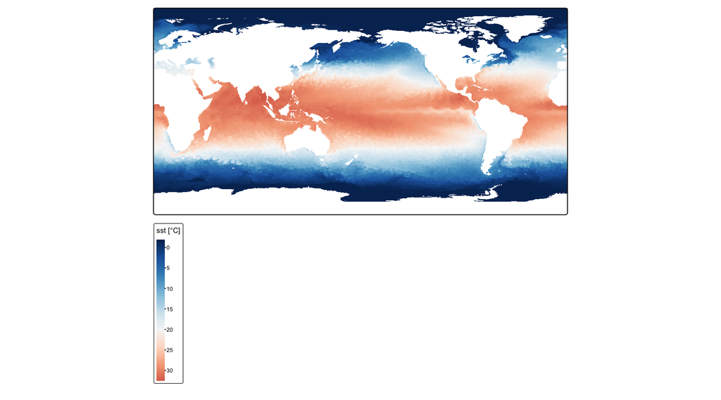

```r
library(stars)
library(tmap)
library(magrittr)
library(devtools)

load_all()

# Example usage
myregion <- "/Users/rof011/rCDO/data/GBRbounds.txt"
infile <- "/Users/rof011/rCDO/data/ncdc_oisst_v2_avhrr_prelim_by_time_zlev_lat_lon_25c1_e82d_d183.nc"
outfile <- "/Users/rof011/rCDO/data/tmp.nc"

#plot
map <- read_ncdf(infile)
tm_shape(map) + tm_raster(col.scale = tm_scale_continuous(values="-rd_bu", midpoint=20))
```

#### ii) maskregion

Using a mask for the Great Barrier Reef Region in the points format of `CDO`

```r
# read points mask
head(read.table(myregion))
```

```
##         V1        V2
## 1 154.0532 -24.60181
## 2 153.0148 -20.89611
## 3 147.1013 -17.36414
## 4 145.2259 -13.22831
## 5 145.1376 -10.64114
## 6 142.4465 -10.58726
```

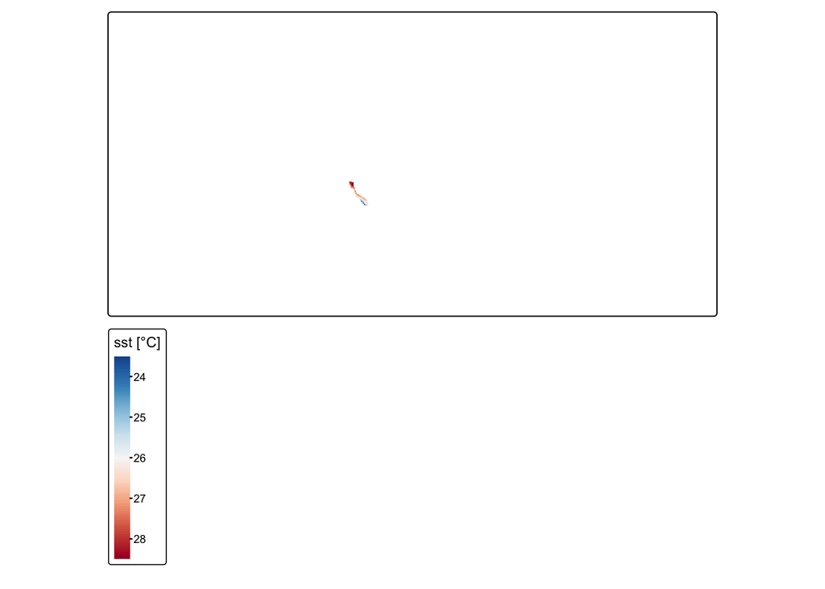

```r
# run rCDO
read_cdo(infile) %>%
  operator("maskregion", myregion) %>%
  write_cdo(outfile)

#plot
map <- read_ncdf(outfile)
tm_shape(map) + tm_raster(col.scale = tm_scale_continuous(values="-rd_bu", midpoint=26))
```

#### iii) sellonlatbox

crop to a boundary box using `CDO` `sellonlatbox`

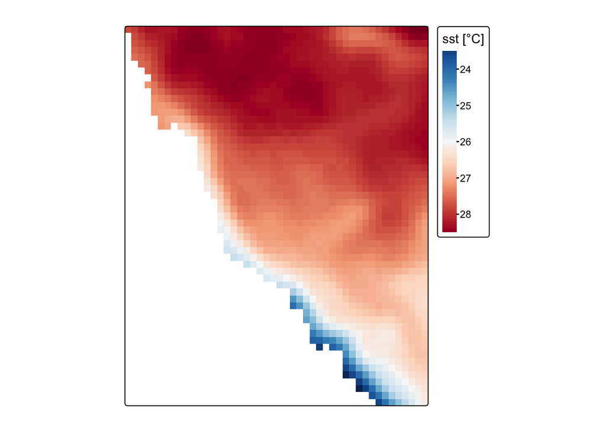

```r
# boundary box in the format of xmin, xmax, ymin, ymax
boundarybox <- c(142.53, 154, -24.49, -10.68)

# run rCDO
read_cdo(infile) %>%
  operator("sellonlatbox", boundarybox) %>%
  write_cdo(outfile)

# plot
map <- read_ncdf(outfile)
tm_shape(map) +
  tm_raster(col.scale = tm_scale_continuous(values="-rd_bu", midpoint=26))
```

#### iv) combined functions

Now combine the two functions to first mask then crop to the region:

```r
# boundary box in the format of xmin, xmax, ymin, ymax
boundarybox <- c(142.53, 154, -24.49, -10.68)

# run rCDO
read_cdo(infile) %>%
  operator("maskregion", myregion) %>%
  operator("sellonlatbox", boundarybox) %>%
  write_cdo(outfile)

# plot
ausmap <- rnaturalearth::ne_countries(country="Australia", scale="large") # load map

map <- read_ncdf(outfile)
```

```
## no 'var' specified, using sst
```

```
## other available variables:
##  time, longitude, latitude, depth
```

```
## Will return stars object with 2530 cells.
```

```
## No projection information found in nc file.
##  Coordinate variable units found to be degrees,
##  assuming WGS84 Lat/Lon.
```

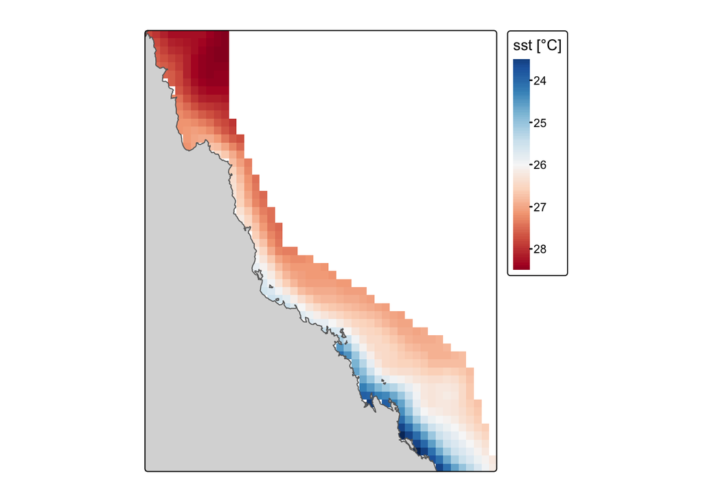

```r
tm_shape(map, is.master=TRUE) +
  tm_raster(col.scale = tm_scale_continuous(values="-rd_bu", midpoint=26)) +
tm_shape(ausmap) +
  tm_polygons()
```

#### v) Regridding with CDO

continuing from the previous example, let’s say we want to downsample and regrid OISST to match 1° gridcells. We can pipe operators as follows:

mask > crop > regrid

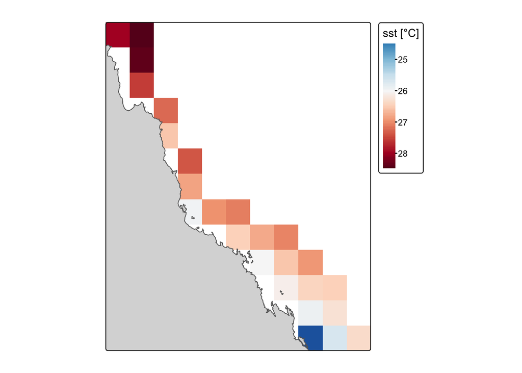

```r
read_cdo(infile) %>%
  operator("maskregion", myregion) %>%
  operator("sellonlatbox", boundarybox) %>%
  operator("remapbil", "global_1") %>%
  write_cdo(outfile)

map <- read_ncdf(outfile)

tm_shape(map, is.master=TRUE) +
  tm_raster(col.scale = tm_scale_continuous(values="-rd_bu", midpoint=26)) +
tm_shape(ausmap) +
  tm_polygons()
```

### Temporal subsetting with CDO

#### i) global OISST timeseries

Read in dataset with `stars` and plot timeseries with ‘ggplot’

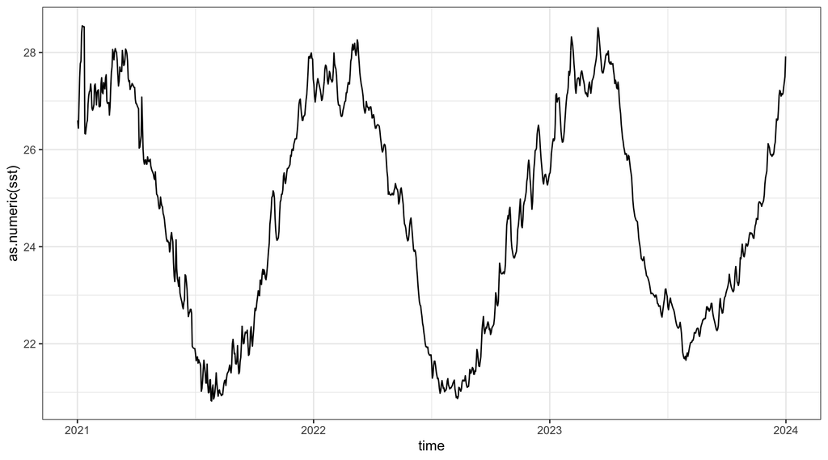

```r
library(ggplot2)

# Example usage
infile <- "/Users/rof011/rCDO/data/ncdc_oisst_v2_avhrr_by_time_zlev_lat_lon_b25f_64c0_90ed.nc"
outfile <- "/Users/rof011/rCDO/data/tmp.nc"

#plot
timeseries <- read_ncdf(infile) |> as.data.frame()

ggplot() + theme_bw() +
  geom_line(data=timeseries, aes(x=time, y=as.numeric(sst)))
```

#### i) ymonavg

compute statistical values of each month of year with stdev

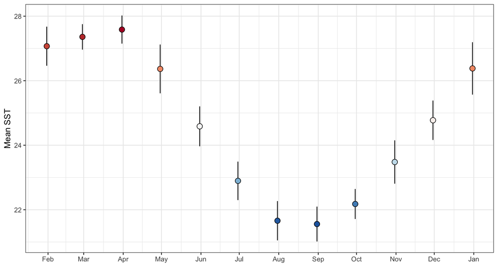

```r
library(dplyr)

# OISST input
infile <- "/Users/rof011/rCDO/data/ncdc_oisst_v2_avhrr_by_time_zlev_lat_lon_b25f_64c0_90ed.nc"
# set output files
mean <- "/Users/rof011/rCDO/data/tmp_mean.nc"
stdev <- "/Users/rof011/rCDO/data/tmp_stdev.nc"

# get monthly mean
read_cdo(infile) %>%
  operator("ymonmean") %>%
  write_cdo(mean)

# get monthly stdev
read_cdo(infile) %>%
  operator("ymonstd") %>%
  write_cdo(stdev)


monthly_mean <- read_ncdf(mean) |> as.data.frame() |> rename(mean=sst)
monthly_stdev <- read_ncdf(stdev) |> as.data.frame() |> rename(std=sst)

monthly <- left_join(monthly_mean, monthly_stdev)


ggplot() + theme_bw() +
  geom_errorbar(data=monthly, aes(x=as.Date(time),
                                       ymin=as.numeric(mean)-as.numeric(std),
                                       ymax=as.numeric(mean)+as.numeric(std)), width=0) +
  geom_point(data=monthly, aes(x=as.Date(time), y=as.numeric(mean), fill=as.numeric(mean)),
             size=3, shape=21, show.legend=FALSE) +
  scale_x_date(date_labels = "%b", date_breaks = "1 month") + xlab("") + ylab("Mean SST") +
  scale_fill_distiller(palette="RdBu")
```